# Risk Factor Analysis

## Outcome Variable

**Outcome Variable:** pers_wast

## Predictor Variables

**Intervention Variable:** enstunt

**Adjustment Set:**

- arm
- sex
- W_mage
- meducyrs
- feducyrs
- vagbrth
- single
- brthmon
- delta_W_mage
- delta_meducyrs
- delta_feducyrs
- delta_vagbrth
- delta_single
- delta_brthmon

## Stratifying Variables

The analysis was stratified on these variable(s):

- agecat
- studyid
- country

## Data Summary

| agecat | studyid | country | enstunt | pers_wast | n_cell | n |
| --- | --- | --- | --- | --- | --- | --- |
| 0-24 months | ki0047075b-MAL-ED | BANGLADESH | 0 | 0 | 198 | 248 |
| 0-24 months | ki0047075b-MAL-ED | BANGLADESH | 0 | 1 | 9 | 248 |
| 0-24 months | ki0047075b-MAL-ED | BANGLADESH | 1 | 0 | 37 | 248 |
| 0-24 months | ki0047075b-MAL-ED | BANGLADESH | 1 | 1 | 4 | 248 |
| 0-24 months | ki0047075b-MAL-ED | BRAZIL | 0 | 0 | 194 | 217 |
| 0-24 months | ki0047075b-MAL-ED | BRAZIL | 0 | 1 | 2 | 217 |
| 0-24 months | ki0047075b-MAL-ED | BRAZIL | 1 | 0 | 21 | 217 |
| 0-24 months | ki0047075b-MAL-ED | BRAZIL | 1 | 1 | 0 | 217 |
| 0-24 months | ki0047075b-MAL-ED | INDIA | 0 | 0 | 183 | 241 |
| 0-24 months | ki0047075b-MAL-ED | INDIA | 0 | 1 | 17 | 241 |
| 0-24 months | ki0047075b-MAL-ED | INDIA | 1 | 0 | 37 | 241 |
| 0-24 months | ki0047075b-MAL-ED | INDIA | 1 | 1 | 4 | 241 |
| 0-24 months | ki0047075b-MAL-ED | NEPAL | 0 | 0 | 208 | 238 |
| 0-24 months | ki0047075b-MAL-ED | NEPAL | 0 | 1 | 3 | 238 |
| 0-24 months | ki0047075b-MAL-ED | NEPAL | 1 | 0 | 26 | 238 |
| 0-24 months | ki0047075b-MAL-ED | NEPAL | 1 | 1 | 1 | 238 |
| 0-24 months | ki0047075b-MAL-ED | PERU | 0 | 0 | 247 | 284 |
| 0-24 months | ki0047075b-MAL-ED | PERU | 0 | 1 | 1 | 284 |
| 0-24 months | ki0047075b-MAL-ED | PERU | 1 | 0 | 36 | 284 |
| 0-24 months | ki0047075b-MAL-ED | PERU | 1 | 1 | 0 | 284 |
| 0-24 months | ki0047075b-MAL-ED | SOUTH AFRICA | 0 | 0 | 243 | 273 |
| 0-24 months | ki0047075b-MAL-ED | SOUTH AFRICA | 0 | 1 | 2 | 273 |
| 0-24 months | ki0047075b-MAL-ED | SOUTH AFRICA | 1 | 0 | 28 | 273 |
| 0-24 months | ki0047075b-MAL-ED | SOUTH AFRICA | 1 | 1 | 0 | 273 |
| 0-24 months | ki0047075b-MAL-ED | TANZANIA, UNITED REPUBLIC OF | 0 | 0 | 214 | 253 |
| 0-24 months | ki0047075b-MAL-ED | TANZANIA, UNITED REPUBLIC OF | 0 | 1 | 0 | 253 |
| 0-24 months | ki0047075b-MAL-ED | TANZANIA, UNITED REPUBLIC OF | 1 | 0 | 39 | 253 |
| 0-24 months | ki0047075b-MAL-ED | TANZANIA, UNITED REPUBLIC OF | 1 | 1 | 0 | 253 |
| 0-24 months | ki1000108-CMC-V-BCS-2002 | INDIA | 0 | 0 | 283 | 373 |
| 0-24 months | ki1000108-CMC-V-BCS-2002 | INDIA | 0 | 1 | 15 | 373 |

[output cut: 342 more lines]

The following strata were considered:

- agecat: 0-24 months, studyid: ki0047075b-MAL-ED, country: BANGLADESH
- agecat: 0-24 months, studyid: ki0047075b-MAL-ED, country: BRAZIL
- agecat: 0-24 months, studyid: ki0047075b-MAL-ED, country: INDIA
- agecat: 0-24 months, studyid: ki0047075b-MAL-ED, country: NEPAL
- agecat: 0-24 months, studyid: ki0047075b-MAL-ED, country: PERU
- agecat: 0-24 months, studyid: ki0047075b-MAL-ED, country: SOUTH AFRICA
- agecat: 0-24 months, studyid: ki0047075b-MAL-ED, country: TANZANIA, UNITED REPUBLIC OF
- agecat: 0-24 months, studyid: ki1000108-CMC-V-BCS-2002, country: INDIA
- agecat: 0-24 months, studyid: ki1000108-IRC, country: INDIA
- agecat: 0-24 months, studyid: ki1000109-EE, country: PAKISTAN
- agecat: 0-24 months, studyid: ki1000109-ResPak, country: PAKISTAN
- agecat: 0-24 months, studyid: ki1000304b-SAS-CompFeed, country: INDIA
- agecat: 0-24 months, studyid: ki1000304b-SAS-FoodSuppl, country: INDIA
- agecat: 0-24 months, studyid: ki1017093-NIH-Birth, country: BANGLADESH
- agecat: 0-24 months, studyid: ki1017093b-PROVIDE, country: BANGLADESH
- agecat: 0-24 months, studyid: ki1017093c-NIH-Crypto, country: BANGLADESH
- agecat: 0-24 months, studyid: ki1066203-TanzaniaChild2, country: TANZANIA, UNITED REPUBLIC OF
- agecat: 0-24 months, studyid: ki1101329-Keneba, country: GAMBIA
- agecat: 0-24 months, studyid: ki1112895-Guatemala BSC, country: GUATEMALA
- agecat: 0-24 months, studyid: ki1112895-iLiNS-Zinc, country: BURKINA FASO
- agecat: 0-24 months, studyid: ki1113344-GMS-Nepal, country: NEPAL
- agecat: 0-24 months, studyid: ki1114097-CMIN, country: BANGLADESH
- agecat: 0-24 months, studyid: ki1114097-CMIN, country: BRAZIL
- agecat: 0-24 months, studyid: ki1114097-CMIN, country: GUINEA-BISSAU
- agecat: 0-24 months, studyid: ki1114097-CMIN, country: PERU
- agecat: 0-24 months, studyid: ki1114097-CONTENT, country: PERU
- agecat: 0-24 months, studyid: ki1119695-PROBIT, country: BELARUS
- agecat: 0-24 months, studyid: ki1126311-ZVITAMBO, country: ZIMBABWE
- agecat: 0-24 months, studyid: ki1135781-COHORTS, country: GUATEMALA
- agecat: 0-24 months, studyid: ki1135781-COHORTS, country: INDIA
- agecat: 0-24 months, studyid: ki1135781-COHORTS, country: PHILIPPINES
- agecat: 0-24 months, studyid: ki1148112-LCNI-5, country: MALAWI
- agecat: 0-24 months, studyid: kiGH5241-JiVitA-3, country: BANGLADESH
- agecat: 0-24 months, studyid: kiGH5241-JiVitA-4, country: BANGLADESH
- agecat: 0-6 months, studyid: ki0047075b-MAL-ED, country: BANGLADESH
- agecat: 0-6 months, studyid: ki0047075b-MAL-ED, country: BRAZIL
- agecat: 0-6 months, studyid: ki0047075b-MAL-ED, country: INDIA
- agecat: 0-6 months, studyid: ki0047075b-MAL-ED, country: NEPAL
- agecat: 0-6 months, studyid: ki0047075b-MAL-ED, country: PERU
- agecat: 0-6 months, studyid: ki0047075b-MAL-ED, country: SOUTH AFRICA
- agecat: 0-6 months, studyid: ki0047075b-MAL-ED, country: TANZANIA, UNITED REPUBLIC OF
- agecat: 0-6 months, studyid: ki1000108-CMC-V-BCS-2002, country: INDIA
- agecat: 0-6 months, studyid: ki1000108-IRC, country: INDIA
- agecat: 0-6 months, studyid: ki1000109-EE, country: PAKISTAN
- agecat: 0-6 months, studyid: ki1000109-ResPak, country: PAKISTAN
- agecat: 0-6 months, studyid: ki1017093-NIH-Birth, country: BANGLADESH
- agecat: 0-6 months, studyid: ki1017093b-PROVIDE, country: BANGLADESH
- agecat: 0-6 months, studyid: ki1017093c-NIH-Crypto, country: BANGLADESH
- agecat: 0-6 months, studyid: ki1066203-TanzaniaChild2, country: TANZANIA, UNITED REPUBLIC OF
- agecat: 0-6 months, studyid: ki1101329-Keneba, country: GAMBIA
- agecat: 0-6 months, studyid: ki1113344-GMS-Nepal, country: NEPAL
- agecat: 0-6 months, studyid: ki1114097-CMIN, country: BANGLADESH
- agecat: 0-6 months, studyid: ki1114097-CMIN, country: GUINEA-BISSAU
- agecat: 0-6 months, studyid: ki1114097-CMIN, country: PERU
- agecat: 0-6 months, studyid: ki1114097-CONTENT, country: PERU
- agecat: 0-6 months, studyid: ki1119695-PROBIT, country: BELARUS
- agecat: 0-6 months, studyid: ki1126311-ZVITAMBO, country: ZIMBABWE
- agecat: 0-6 months, studyid: ki1135781-COHORTS, country: PHILIPPINES
- agecat: 0-6 months, studyid: kiGH5241-JiVitA-3, country: BANGLADESH
- agecat: 6-24 months, studyid: ki0047075b-MAL-ED, country: BANGLADESH
- agecat: 6-24 months, studyid: ki0047075b-MAL-ED, country: BRAZIL
- agecat: 6-24 months, studyid: ki0047075b-MAL-ED, country: INDIA
- agecat: 6-24 months, studyid: ki0047075b-MAL-ED, country: NEPAL
- agecat: 6-24 months, studyid: ki0047075b-MAL-ED, country: PERU
- agecat: 6-24 months, studyid: ki0047075b-MAL-ED, country: SOUTH AFRICA
- agecat: 6-24 months, studyid: ki0047075b-MAL-ED, country: TANZANIA, UNITED REPUBLIC OF
- agecat: 6-24 months, studyid: ki1000108-CMC-V-BCS-2002, country: INDIA
- agecat: 6-24 months, studyid: ki1000108-IRC, country: INDIA
- agecat: 6-24 months, studyid: ki1000109-EE, country: PAKISTAN
- agecat: 6-24 months, studyid: ki1000109-ResPak, country: PAKISTAN
- agecat: 6-24 months, studyid: ki1000304b-SAS-CompFeed, country: INDIA
- agecat: 6-24 months, studyid: ki1000304b-SAS-FoodSuppl, country: INDIA
- agecat: 6-24 months, studyid: ki1017093-NIH-Birth, country: BANGLADESH
- agecat: 6-24 months, studyid: ki1017093b-PROVIDE, country: BANGLADESH
- agecat: 6-24 months, studyid: ki1017093c-NIH-Crypto, country: BANGLADESH
- agecat: 6-24 months, studyid: ki1066203-TanzaniaChild2, country: TANZANIA, UNITED REPUBLIC OF
- agecat: 6-24 months, studyid: ki1101329-Keneba, country: GAMBIA
- agecat: 6-24 months, studyid: ki1112895-Guatemala BSC, country: GUATEMALA
- agecat: 6-24 months, studyid: ki1112895-iLiNS-Zinc, country: BURKINA FASO
- agecat: 6-24 months, studyid: ki1113344-GMS-Nepal, country: NEPAL
- agecat: 6-24 months, studyid: ki1114097-CMIN, country: BANGLADESH
- agecat: 6-24 months, studyid: ki1114097-CMIN, country: BRAZIL
- agecat: 6-24 months, studyid: ki1114097-CMIN, country: GUINEA-BISSAU
- agecat: 6-24 months, studyid: ki1114097-CMIN, country: PERU
- agecat: 6-24 months, studyid: ki1114097-CONTENT, country: PERU
- agecat: 6-24 months, studyid: ki1119695-PROBIT, country: BELARUS
- agecat: 6-24 months, studyid: ki1126311-ZVITAMBO, country: ZIMBABWE
- agecat: 6-24 months, studyid: ki1135781-COHORTS, country: GUATEMALA
- agecat: 6-24 months, studyid: ki1135781-COHORTS, country: INDIA
- agecat: 6-24 months, studyid: ki1135781-COHORTS, country: PHILIPPINES
- agecat: 6-24 months, studyid: ki1148112-LCNI-5, country: MALAWI
- agecat: 6-24 months, studyid: kiGH5241-JiVitA-3, country: BANGLADESH
- agecat: 6-24 months, studyid: kiGH5241-JiVitA-4, country: BANGLADESH

### Dropped Strata

Some strata were dropped due to rare outcomes:

- agecat: 0-24 months, studyid: ki0047075b-MAL-ED, country: BANGLADESH
- agecat: 0-24 months, studyid: ki0047075b-MAL-ED, country: BRAZIL
- agecat: 0-24 months, studyid: ki0047075b-MAL-ED, country: INDIA
- agecat: 0-24 months, studyid: ki0047075b-MAL-ED, country: NEPAL
- agecat: 0-24 months, studyid: ki0047075b-MAL-ED, country: PERU
- agecat: 0-24 months, studyid: ki0047075b-MAL-ED, country: SOUTH AFRICA
- agecat: 0-24 months, studyid: ki0047075b-MAL-ED, country: TANZANIA, UNITED REPUBLIC OF
- agecat: 0-24 months, studyid: ki1017093b-PROVIDE, country: BANGLADESH
- agecat: 0-24 months, studyid: ki1066203-TanzaniaChild2, country: TANZANIA, UNITED REPUBLIC OF
- agecat: 0-24 months, studyid: ki1112895-Guatemala BSC, country: GUATEMALA
- agecat: 0-24 months, studyid: ki1114097-CMIN, country: BRAZIL
- agecat: 0-24 months, studyid: ki1114097-CMIN, country: PERU
- agecat: 0-24 months, studyid: ki1114097-CONTENT, country: PERU
- agecat: 0-24 months, studyid: ki1119695-PROBIT, country: BELARUS
- agecat: 0-24 months, studyid: ki1148112-LCNI-5, country: MALAWI
- agecat: 0-6 months, studyid: ki0047075b-MAL-ED, country: BANGLADESH
- agecat: 0-6 months, studyid: ki0047075b-MAL-ED, country: BRAZIL
- agecat: 0-6 months, studyid: ki0047075b-MAL-ED, country: INDIA
- agecat: 0-6 months, studyid: ki0047075b-MAL-ED, country: NEPAL
- agecat: 0-6 months, studyid: ki0047075b-MAL-ED, country: PERU
- agecat: 0-6 months, studyid: ki0047075b-MAL-ED, country: SOUTH AFRICA
- agecat: 0-6 months, studyid: ki0047075b-MAL-ED, country: TANZANIA, UNITED REPUBLIC OF
- agecat: 0-6 months, studyid: ki1017093-NIH-Birth, country: BANGLADESH
- agecat: 0-6 months, studyid: ki1017093b-PROVIDE, country: BANGLADESH
- agecat: 0-6 months, studyid: ki1017093c-NIH-Crypto, country: BANGLADESH
- agecat: 0-6 months, studyid: ki1066203-TanzaniaChild2, country: TANZANIA, UNITED REPUBLIC OF
- agecat: 0-6 months, studyid: ki1114097-CMIN, country: BANGLADESH
- agecat: 0-6 months, studyid: ki1114097-CMIN, country: GUINEA-BISSAU
- agecat: 0-6 months, studyid: ki1114097-CMIN, country: PERU
- agecat: 0-6 months, studyid: ki1114097-CONTENT, country: PERU
- agecat: 0-6 months, studyid: ki1119695-PROBIT, country: BELARUS
- agecat: 0-6 months, studyid: ki1126311-ZVITAMBO, country: ZIMBABWE
- agecat: 0-6 months, studyid: ki1135781-COHORTS, country: PHILIPPINES
- agecat: 0-6 months, studyid: kiGH5241-JiVitA-3, country: BANGLADESH
- agecat: 6-24 months, studyid: ki0047075b-MAL-ED, country: BANGLADESH
- agecat: 6-24 months, studyid: ki0047075b-MAL-ED, country: BRAZIL
- agecat: 6-24 months, studyid: ki0047075b-MAL-ED, country: INDIA
- agecat: 6-24 months, studyid: ki0047075b-MAL-ED, country: NEPAL
- agecat: 6-24 months, studyid: ki0047075b-MAL-ED, country: PERU
- agecat: 6-24 months, studyid: ki0047075b-MAL-ED, country: SOUTH AFRICA
- agecat: 6-24 months, studyid: ki0047075b-MAL-ED, country: TANZANIA, UNITED REPUBLIC OF
- agecat: 6-24 months, studyid: ki1017093b-PROVIDE, country: BANGLADESH
- agecat: 6-24 months, studyid: ki1066203-TanzaniaChild2, country: TANZANIA, UNITED REPUBLIC OF
- agecat: 6-24 months, studyid: ki1112895-Guatemala BSC, country: GUATEMALA
- agecat: 6-24 months, studyid: ki1114097-CMIN, country: BRAZIL
- agecat: 6-24 months, studyid: ki1114097-CMIN, country: PERU
- agecat: 6-24 months, studyid: ki1114097-CONTENT, country: PERU
- agecat: 6-24 months, studyid: ki1119695-PROBIT, country: BELARUS
- agecat: 6-24 months, studyid: ki1148112-LCNI-5, country: MALAWI

## Methods Detail

We’re interested in the causal parameters $E[Y_a]$ for all values of $a \in \mathcal{A}$. These parameters represent the mean outcome if, possibly contrary to fact, we intervened to set all units to have $A=a$. Under the randomization and positivity assumptions, these are identified by the statistical parameters $\psi_a=E_W[E_{Y|A,W}(Y|A=a,W)]$. In addition, we’re interested in the mean of $Y$, $E[Y]$ under no intervention (the observed mean). We will estimate these parameters by using SuperLearner to fit the relevant likelihood factors – $E_{Y|A,W}(Y|A=a,W)$ and $p(A=a|W)$, and then updating our likelihood fit using a joint TMLE.

For unadjusted analyses ($W=\{\}$), initial likelihoods were estimated using Lrnr_glm to estimate the simple $E(Y|A)$ and Lrnr_mean to estimate $p(A)$. For adjusted analyses, a small library containing Lrnr_glmnet, Lrnr_xgboost, and Lrnr_mean was used.

Having estimated these parameters, we will then use the delta method to estimate relative risks and attributable risks relative to a prespecified baseline level of $A$.

# Results Detail

## Results Plots

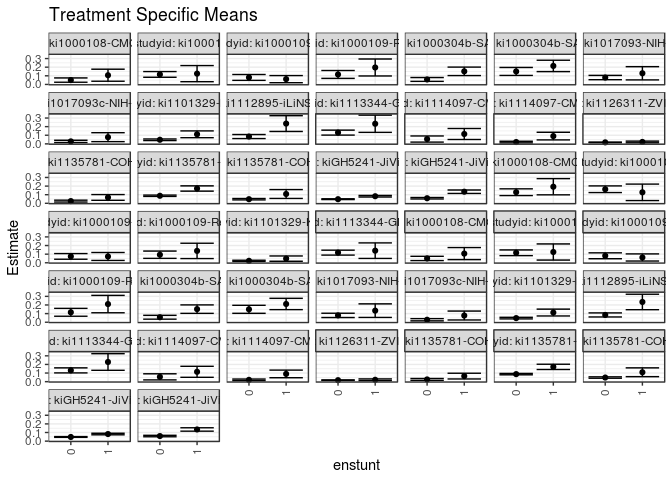

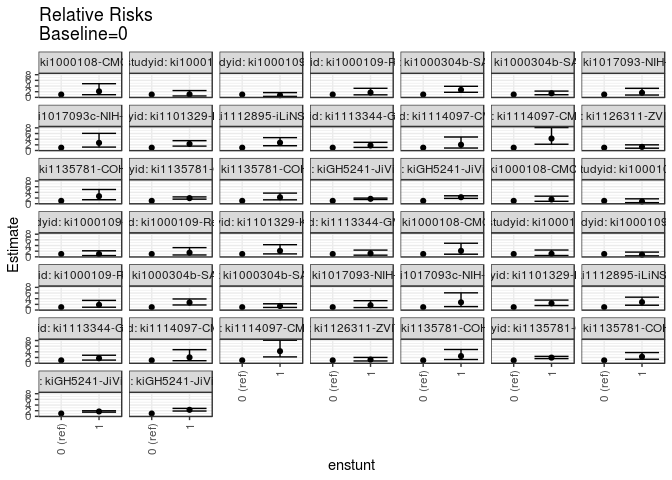

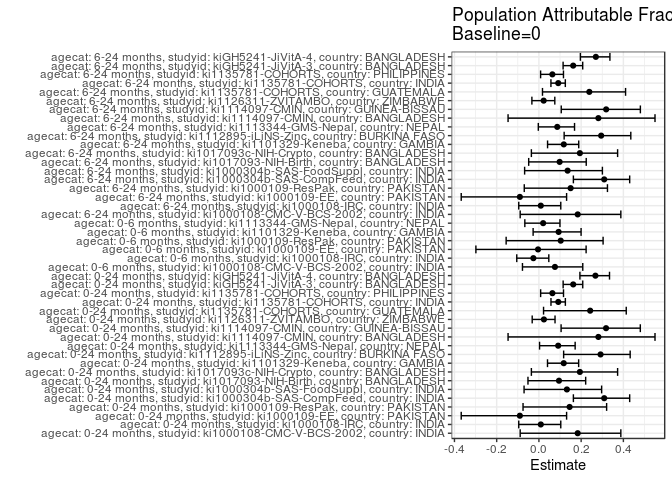

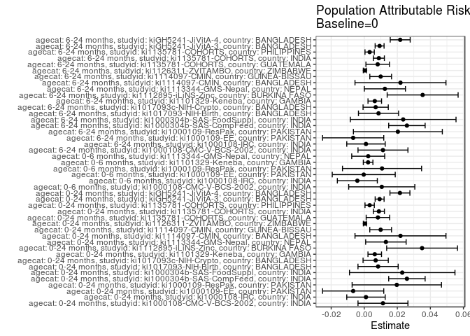

## Results Table

### Parameter: TSM

| agecat | studyid | country | intervention_level | baseline_level | estimate | ci_lower | ci_upper |
| --- | --- | --- | --- | --- | --- | --- | --- |
| 0-24 months | ki1000108-CMC-V-BCS-2002 | INDIA | 0 | NA | 0.0503356 | 0.0254788 | 0.0751924 |
| 0-24 months | ki1000108-CMC-V-BCS-2002 | INDIA | 1 | NA | 0.1066667 | 0.0367112 | 0.1766221 |
| 0-24 months | ki1000108-IRC | INDIA | 0 | NA | 0.1160221 | 0.0829916 | 0.1490526 |
| 0-24 months | ki1000108-IRC | INDIA | 1 | NA | 0.1250000 | 0.0313265 | 0.2186735 |
| 0-24 months | ki1000109-EE | PAKISTAN | 0 | NA | 0.0809717 | 0.0469067 | 0.1150366 |
| 0-24 months | ki1000109-EE | PAKISTAN | 1 | NA | 0.0615385 | 0.0201733 | 0.1029036 |
| 0-24 months | ki1000109-ResPak | PAKISTAN | 0 | NA | 0.1157714 | 0.0699254 | 0.1616174 |
| 0-24 months | ki1000109-ResPak | PAKISTAN | 1 | NA | 0.1963713 | 0.0977859 | 0.2949568 |
| 0-24 months | ki1000304b-SAS-CompFeed | INDIA | 0 | NA | 0.0576446 | 0.0353400 | 0.0799492 |
| 0-24 months | ki1000304b-SAS-CompFeed | INDIA | 1 | NA | 0.1519132 | 0.1026431 | 0.2011833 |
| 0-24 months | ki1000304b-SAS-FoodSuppl | INDIA | 0 | NA | 0.1503546 | 0.1039903 | 0.1967190 |
| 0-24 months | ki1000304b-SAS-FoodSuppl | INDIA | 1 | NA | 0.2146074 | 0.1486422 | 0.2805726 |
| 0-24 months | ki1017093-NIH-Birth | BANGLADESH | 0 | NA | 0.0796484 | 0.0546204 | 0.1046765 |
| 0-24 months | ki1017093-NIH-Birth | BANGLADESH | 1 | NA | 0.1292487 | 0.0524106 | 0.2060868 |
| 0-24 months | ki1017093c-NIH-Crypto | BANGLADESH | 0 | NA | 0.0287081 | 0.0156287 | 0.0417876 |
| 0-24 months | ki1017093c-NIH-Crypto | BANGLADESH | 1 | NA | 0.0776699 | 0.0259454 | 0.1293945 |
| 0-24 months | ki1101329-Keneba | GAMBIA | 0 | NA | 0.0477217 | 0.0387892 | 0.0566542 |
| 0-24 months | ki1101329-Keneba | GAMBIA | 1 | NA | 0.1111349 | 0.0716415 | 0.1506283 |
| 0-24 months | ki1112895-iLiNS-Zinc | BURKINA FASO | 0 | NA | 0.0848500 | 0.0614513 | 0.1082488 |
| 0-24 months | ki1112895-iLiNS-Zinc | BURKINA FASO | 1 | NA | 0.2353709 | 0.1439615 | 0.3267802 |
| 0-24 months | ki1113344-GMS-Nepal | NEPAL | 0 | NA | 0.1304842 | 0.1015815 | 0.1593868 |
| 0-24 months | ki1113344-GMS-Nepal | NEPAL | 1 | NA | 0.2333769 | 0.1334022 | 0.3333515 |
| 0-24 months | ki1114097-CMIN | BANGLADESH | 0 | NA | 0.0559006 | 0.0203458 | 0.0914555 |
| 0-24 months | ki1114097-CMIN | BANGLADESH | 1 | NA | 0.1145833 | 0.0507432 | 0.1784234 |
| 0-24 months | ki1114097-CMIN | GUINEA-BISSAU | 0 | NA | 0.0212962 | 0.0122784 | 0.0303141 |
| 0-24 months | ki1114097-CMIN | GUINEA-BISSAU | 1 | NA | 0.0901720 | 0.0458732 | 0.1344709 |
| 0-24 months | ki1126311-ZVITAMBO | ZIMBABWE | 0 | NA | 0.0174688 | 0.0146700 | 0.0202676 |
| 0-24 months | ki1126311-ZVITAMBO | ZIMBABWE | 1 | NA | 0.0224002 | 0.0129721 | 0.0318282 |
| 0-24 months | ki1135781-COHORTS | GUATEMALA | 0 | NA | 0.0258176 | 0.0151850 | 0.0364502 |
| 0-24 months | ki1135781-COHORTS | GUATEMALA | 1 | NA | 0.0683026 | 0.0351503 | 0.1014548 |

[output cut: 58 more lines]

### Parameter: E(Y)

| agecat | studyid | country | intervention_level | baseline_level | estimate | ci_lower | ci_upper |
| --- | --- | --- | --- | --- | --- | --- | --- |
| 0-24 months | ki1000108-CMC-V-BCS-2002 | INDIA | NA | NA | 0.0616622 | 0.0372186 | 0.0861058 |
| 0-24 months | ki1000108-IRC | INDIA | NA | NA | 0.1170732 | 0.0859146 | 0.1482317 |
| 0-24 months | ki1000109-EE | PAKISTAN | NA | NA | 0.0742706 | 0.0477670 | 0.1007741 |
| 0-24 months | ki1000109-ResPak | PAKISTAN | NA | NA | 0.1354582 | 0.0930379 | 0.1778785 |
| 0-24 months | ki1000304b-SAS-CompFeed | INDIA | NA | NA | 0.0834553 | 0.0601989 | 0.1067118 |
| 0-24 months | ki1000304b-SAS-FoodSuppl | INDIA | NA | NA | 0.1733333 | 0.1349698 | 0.2116969 |
| 0-24 months | ki1017093-NIH-Birth | BANGLADESH | NA | NA | 0.0880150 | 0.0639627 | 0.1120673 |
| 0-24 months | ki1017093c-NIH-Crypto | BANGLADESH | NA | NA | 0.0356164 | 0.0221630 | 0.0490699 |
| 0-24 months | ki1101329-Keneba | GAMBIA | NA | NA | 0.0540762 | 0.0451022 | 0.0630502 |
| 0-24 months | ki1112895-iLiNS-Zinc | BURKINA FASO | NA | NA | 0.1198322 | 0.0943748 | 0.1452897 |
| 0-24 months | ki1113344-GMS-Nepal | NEPAL | NA | NA | 0.1435811 | 0.1153098 | 0.1718524 |
| 0-24 months | ki1114097-CMIN | BANGLADESH | NA | NA | 0.0778210 | 0.0450051 | 0.1106369 |
| 0-24 months | ki1114097-CMIN | GUINEA-BISSAU | NA | NA | 0.0312229 | 0.0211797 | 0.0412661 |
| 0-24 months | ki1126311-ZVITAMBO | ZIMBABWE | NA | NA | 0.0178935 | 0.0152039 | 0.0205831 |
| 0-24 months | ki1135781-COHORTS | GUATEMALA | NA | NA | 0.0340909 | 0.0231410 | 0.0450408 |
| 0-24 months | ki1135781-COHORTS | INDIA | NA | NA | 0.0964067 | 0.0887472 | 0.1040661 |
| 0-24 months | ki1135781-COHORTS | PHILIPPINES | NA | NA | 0.0512273 | 0.0430760 | 0.0593786 |
| 0-24 months | kiGH5241-JiVitA-3 | BANGLADESH | NA | NA | 0.0572741 | 0.0531873 | 0.0613609 |
| 0-24 months | kiGH5241-JiVitA-4 | BANGLADESH | NA | NA | 0.0806665 | 0.0720540 | 0.0892791 |
| 0-6 months | ki1000108-CMC-V-BCS-2002 | INDIA | NA | NA | 0.1396648 | 0.1037072 | 0.1756225 |
| 0-6 months | ki1000108-IRC | INDIA | NA | NA | 0.1592040 | 0.1233945 | 0.1950135 |
| 0-6 months | ki1000109-EE | PAKISTAN | NA | NA | 0.0737705 | 0.0469540 | 0.1005870 |
| 0-6 months | ki1000109-ResPak | PAKISTAN | NA | NA | 0.1041667 | 0.0654385 | 0.1428949 |
| 0-6 months | ki1101329-Keneba | GAMBIA | NA | NA | 0.0250368 | 0.0182504 | 0.0318233 |
| 0-6 months | ki1113344-GMS-Nepal | NEPAL | NA | NA | 0.1199262 | 0.0925504 | 0.1473020 |
| 6-24 months | ki1000108-CMC-V-BCS-2002 | INDIA | NA | NA | 0.0616622 | 0.0372186 | 0.0861058 |
| 6-24 months | ki1000108-IRC | INDIA | NA | NA | 0.1170732 | 0.0859146 | 0.1482317 |
| 6-24 months | ki1000109-EE | PAKISTAN | NA | NA | 0.0742706 | 0.0477670 | 0.1007741 |
| 6-24 months | ki1000109-ResPak | PAKISTAN | NA | NA | 0.1354582 | 0.0930379 | 0.1778785 |
| 6-24 months | ki1000304b-SAS-CompFeed | INDIA | NA | NA | 0.0834553 | 0.0601989 | 0.1067118 |
| 6-24 months | ki1000304b-SAS-FoodSuppl | INDIA | NA | NA | 0.1733333 | 0.1349698 | 0.2116969 |
| 6-24 months | ki1017093-NIH-Birth | BANGLADESH | NA | NA | 0.0880150 | 0.0639627 | 0.1120673 |
| 6-24 months | ki1017093c-NIH-Crypto | BANGLADESH | NA | NA | 0.0356164 | 0.0221630 | 0.0490699 |
| 6-24 months | ki1101329-Keneba | GAMBIA | NA | NA | 0.0540762 | 0.0451022 | 0.0630502 |
| 6-24 months | ki1112895-iLiNS-Zinc | BURKINA FASO | NA | NA | 0.1198322 | 0.0943748 | 0.1452897 |
| 6-24 months | ki1113344-GMS-Nepal | NEPAL | NA | NA | 0.1435811 | 0.1153098 | 0.1718524 |
| 6-24 months | ki1114097-CMIN | BANGLADESH | NA | NA | 0.0778210 | 0.0450051 | 0.1106369 |
| 6-24 months | ki1114097-CMIN | GUINEA-BISSAU | NA | NA | 0.0312229 | 0.0211797 | 0.0412661 |
| 6-24 months | ki1126311-ZVITAMBO | ZIMBABWE | NA | NA | 0.0178935 | 0.0152039 | 0.0205831 |
| 6-24 months | ki1135781-COHORTS | GUATEMALA | NA | NA | 0.0340909 | 0.0231410 | 0.0450408 |
| 6-24 months | ki1135781-COHORTS | INDIA | NA | NA | 0.0964067 | 0.0887472 | 0.1040661 |
| 6-24 months | ki1135781-COHORTS | PHILIPPINES | NA | NA | 0.0512273 | 0.0430760 | 0.0593786 |
| 6-24 months | kiGH5241-JiVitA-3 | BANGLADESH | NA | NA | 0.0572741 | 0.0531873 | 0.0613609 |
| 6-24 months | kiGH5241-JiVitA-4 | BANGLADESH | NA | NA | 0.0806665 | 0.0720540 | 0.0892791 |

### Parameter: RR

| agecat | studyid | country | intervention_level | baseline_level | estimate | ci_lower | ci_upper |
| --- | --- | --- | --- | --- | --- | --- | --- |
| 0-24 months | ki1000108-CMC-V-BCS-2002 | INDIA | 0 | 0 | 1.0000000 | 1.0000000 | 1.000000 |
| 0-24 months | ki1000108-CMC-V-BCS-2002 | INDIA | 1 | 0 | 2.1191111 | 0.9324275 | 4.816065 |
| 0-24 months | ki1000108-IRC | INDIA | 0 | 0 | 1.0000000 | 1.0000000 | 1.000000 |
| 0-24 months | ki1000108-IRC | INDIA | 1 | 0 | 1.0773810 | 0.4833037 | 2.401698 |
| 0-24 months | ki1000109-EE | PAKISTAN | 0 | 0 | 1.0000000 | 1.0000000 | 1.000000 |
| 0-24 months | ki1000109-EE | PAKISTAN | 1 | 0 | 0.7600000 | 0.3438949 | 1.679583 |
| 0-24 months | ki1000109-ResPak | PAKISTAN | 0 | 0 | 1.0000000 | 1.0000000 | 1.000000 |
| 0-24 months | ki1000109-ResPak | PAKISTAN | 1 | 0 | 1.6961985 | 0.8981363 | 3.203399 |
| 0-24 months | ki1000304b-SAS-CompFeed | INDIA | 0 | 0 | 1.0000000 | 1.0000000 | 1.000000 |
| 0-24 months | ki1000304b-SAS-CompFeed | INDIA | 1 | 0 | 2.6353422 | 1.7773674 | 3.907481 |
| 0-24 months | ki1000304b-SAS-FoodSuppl | INDIA | 0 | 0 | 1.0000000 | 1.0000000 | 1.000000 |
| 0-24 months | ki1000304b-SAS-FoodSuppl | INDIA | 1 | 0 | 1.4273415 | 0.9237562 | 2.205456 |
| 0-24 months | ki1017093-NIH-Birth | BANGLADESH | 0 | 0 | 1.0000000 | 1.0000000 | 1.000000 |
| 0-24 months | ki1017093-NIH-Birth | BANGLADESH | 1 | 0 | 1.6227403 | 0.8276084 | 3.181802 |
| 0-24 months | ki1017093c-NIH-Crypto | BANGLADESH | 0 | 0 | 1.0000000 | 1.0000000 | 1.000000 |
| 0-24 months | ki1017093c-NIH-Crypto | BANGLADESH | 1 | 0 | 2.7055016 | 1.2073171 | 6.062814 |
| 0-24 months | ki1101329-Keneba | GAMBIA | 0 | 0 | 1.0000000 | 1.0000000 | 1.000000 |
| 0-24 months | ki1101329-Keneba | GAMBIA | 1 | 0 | 2.3288125 | 1.5587630 | 3.479277 |
| 0-24 months | ki1112895-iLiNS-Zinc | BURKINA FASO | 0 | 0 | 1.0000000 | 1.0000000 | 1.000000 |
| 0-24 months | ki1112895-iLiNS-Zinc | BURKINA FASO | 1 | 0 | 2.7739636 | 1.6903044 | 4.552360 |
| 0-24 months | ki1113344-GMS-Nepal | NEPAL | 0 | 0 | 1.0000000 | 1.0000000 | 1.000000 |
| 0-24 months | ki1113344-GMS-Nepal | NEPAL | 1 | 0 | 1.7885454 | 1.1051518 | 2.894530 |
| 0-24 months | ki1114097-CMIN | BANGLADESH | 0 | 0 | 1.0000000 | 1.0000000 | 1.000000 |
| 0-24 months | ki1114097-CMIN | BANGLADESH | 1 | 0 | 2.0497685 | 0.8800068 | 4.774453 |
| 0-24 months | ki1114097-CMIN | GUINEA-BISSAU | 0 | 0 | 1.0000000 | 1.0000000 | 1.000000 |
| 0-24 months | ki1114097-CMIN | GUINEA-BISSAU | 1 | 0 | 4.2341785 | 2.2124196 | 8.103466 |
| 0-24 months | ki1126311-ZVITAMBO | ZIMBABWE | 0 | 0 | 1.0000000 | 1.0000000 | 1.000000 |
| 0-24 months | ki1126311-ZVITAMBO | ZIMBABWE | 1 | 0 | 1.2822947 | 0.8173599 | 2.011696 |
| 0-24 months | ki1135781-COHORTS | GUATEMALA | 0 | 0 | 1.0000000 | 1.0000000 | 1.000000 |
| 0-24 months | ki1135781-COHORTS | GUATEMALA | 1 | 0 | 2.6455824 | 1.3980547 | 5.006318 |

[output cut: 58 more lines]

### Parameter: PAR

| agecat | studyid | country | intervention_level | baseline_level | estimate | ci_lower | ci_upper |
| --- | --- | --- | --- | --- | --- | --- | --- |
| 0-24 months | ki1000108-CMC-V-BCS-2002 | INDIA | 0 | NA | 0.0113266 | -0.0037763 | 0.0264296 |
| 0-24 months | ki1000108-IRC | INDIA | 0 | NA | 0.0010511 | -0.0105808 | 0.0126829 |
| 0-24 months | ki1000109-EE | PAKISTAN | 0 | NA | -0.0067011 | -0.0252027 | 0.0118005 |
| 0-24 months | ki1000109-ResPak | PAKISTAN | 0 | NA | 0.0196867 | -0.0073382 | 0.0467117 |
| 0-24 months | ki1000304b-SAS-CompFeed | INDIA | 0 | NA | 0.0258108 | 0.0147890 | 0.0368325 |
| 0-24 months | ki1000304b-SAS-FoodSuppl | INDIA | 0 | NA | 0.0229787 | -0.0089250 | 0.0548824 |
| 0-24 months | ki1017093-NIH-Birth | BANGLADESH | 0 | NA | 0.0083666 | -0.0037906 | 0.0205237 |
| 0-24 months | ki1017093c-NIH-Crypto | BANGLADESH | 0 | NA | 0.0069083 | -0.0007205 | 0.0145371 |
| 0-24 months | ki1101329-Keneba | GAMBIA | 0 | NA | 0.0063545 | 0.0022530 | 0.0104560 |
| 0-24 months | ki1112895-iLiNS-Zinc | BURKINA FASO | 0 | NA | 0.0349822 | 0.0135651 | 0.0563994 |
| 0-24 months | ki1113344-GMS-Nepal | NEPAL | 0 | NA | 0.0130969 | 0.0008588 | 0.0253351 |
| 0-24 months | ki1114097-CMIN | BANGLADESH | 0 | NA | 0.0219204 | -0.0055961 | 0.0494369 |
| 0-24 months | ki1114097-CMIN | GUINEA-BISSAU | 0 | NA | 0.0099267 | 0.0033512 | 0.0165021 |
| 0-24 months | ki1126311-ZVITAMBO | ZIMBABWE | 0 | NA | 0.0004247 | -0.0005443 | 0.0013936 |
| 0-24 months | ki1135781-COHORTS | GUATEMALA | 0 | NA | 0.0082733 | 0.0011706 | 0.0153761 |
| 0-24 months | ki1135781-COHORTS | INDIA | 0 | NA | 0.0088513 | 0.0055068 | 0.0121958 |
| 0-24 months | ki1135781-COHORTS | PHILIPPINES | 0 | NA | 0.0032724 | 0.0004573 | 0.0060875 |
| 0-24 months | kiGH5241-JiVitA-3 | BANGLADESH | 0 | NA | 0.0093040 | 0.0066008 | 0.0120071 |
| 0-24 months | kiGH5241-JiVitA-4 | BANGLADESH | 0 | NA | 0.0215846 | 0.0155469 | 0.0276222 |
| 0-6 months | ki1000108-CMC-V-BCS-2002 | INDIA | 0 | NA | 0.0105936 | -0.0094035 | 0.0305908 |
| 0-6 months | ki1000108-IRC | INDIA | 0 | NA | -0.0041763 | -0.0162700 | 0.0079174 |
| 0-6 months | ki1000109-EE | PAKISTAN | 0 | NA | -0.0003036 | -0.0193471 | 0.0187400 |
| 0-6 months | ki1000109-ResPak | PAKISTAN | 0 | NA | 0.0107601 | -0.0131676 | 0.0346877 |
| 0-6 months | ki1101329-Keneba | GAMBIA | 0 | NA | 0.0023341 | -0.0005685 | 0.0052367 |
| 0-6 months | ki1113344-GMS-Nepal | NEPAL | 0 | NA | 0.0024004 | -0.0075769 | 0.0123778 |
| 6-24 months | ki1000108-CMC-V-BCS-2002 | INDIA | 0 | NA | 0.0113266 | -0.0037763 | 0.0264296 |
| 6-24 months | ki1000108-IRC | INDIA | 0 | NA | 0.0010511 | -0.0105808 | 0.0126829 |
| 6-24 months | ki1000109-EE | PAKISTAN | 0 | NA | -0.0067011 | -0.0252027 | 0.0118005 |
| 6-24 months | ki1000109-ResPak | PAKISTAN | 0 | NA | 0.0203389 | -0.0065584 | 0.0472363 |
| 6-24 months | ki1000304b-SAS-CompFeed | INDIA | 0 | NA | 0.0258108 | 0.0147890 | 0.0368325 |
| 6-24 months | ki1000304b-SAS-FoodSuppl | INDIA | 0 | NA | 0.0235553 | -0.0084058 | 0.0555164 |
| 6-24 months | ki1017093-NIH-Birth | BANGLADESH | 0 | NA | 0.0086323 | -0.0035001 | 0.0207647 |
| 6-24 months | ki1017093c-NIH-Crypto | BANGLADESH | 0 | NA | 0.0069083 | -0.0007205 | 0.0145371 |
| 6-24 months | ki1101329-Keneba | GAMBIA | 0 | NA | 0.0063712 | 0.0022678 | 0.0104745 |
| 6-24 months | ki1112895-iLiNS-Zinc | BURKINA FASO | 0 | NA | 0.0353233 | 0.0138661 | 0.0567804 |
| 6-24 months | ki1113344-GMS-Nepal | NEPAL | 0 | NA | 0.0124817 | 0.0000433 | 0.0249201 |
| 6-24 months | ki1114097-CMIN | BANGLADESH | 0 | NA | 0.0219204 | -0.0055961 | 0.0494369 |
| 6-24 months | ki1114097-CMIN | GUINEA-BISSAU | 0 | NA | 0.0099417 | 0.0033729 | 0.0165105 |
| 6-24 months | ki1126311-ZVITAMBO | ZIMBABWE | 0 | NA | 0.0004025 | -0.0005694 | 0.0013745 |
| 6-24 months | ki1135781-COHORTS | GUATEMALA | 0 | NA | 0.0081356 | 0.0010166 | 0.0152547 |
| 6-24 months | ki1135781-COHORTS | INDIA | 0 | NA | 0.0088311 | 0.0054859 | 0.0121763 |
| 6-24 months | ki1135781-COHORTS | PHILIPPINES | 0 | NA | 0.0032639 | 0.0004497 | 0.0060780 |
| 6-24 months | kiGH5241-JiVitA-3 | BANGLADESH | 0 | NA | 0.0092932 | 0.0065900 | 0.0119964 |
| 6-24 months | kiGH5241-JiVitA-4 | BANGLADESH | 0 | NA | 0.0217498 | 0.0157125 | 0.0277871 |

### Parameter: PAF

| agecat | studyid | country | intervention_level | baseline_level | estimate | ci_lower | ci_upper |
| --- | --- | --- | --- | --- | --- | --- | --- |
| 0-24 months | ki1000108-CMC-V-BCS-2002 | INDIA | 0 | NA | 0.1836884 | -0.0887240 | 0.3879397 |
| 0-24 months | ki1000108-IRC | INDIA | 0 | NA | 0.0089779 | -0.0955050 | 0.1034958 |
| 0-24 months | ki1000109-EE | PAKISTAN | 0 | NA | -0.0902256 | -0.3679311 | 0.1311026 |
| 0-24 months | ki1000109-ResPak | PAKISTAN | 0 | NA | 0.1453344 | -0.0751822 | 0.3206237 |
| 0-24 months | ki1000304b-SAS-CompFeed | INDIA | 0 | NA | 0.3092763 | 0.1632448 | 0.4298221 |
| 0-24 months | ki1000304b-SAS-FoodSuppl | INDIA | 0 | NA | 0.1325693 | -0.0703212 | 0.2969999 |
| 0-24 months | ki1017093-NIH-Birth | BANGLADESH | 0 | NA | 0.0950584 | -0.0518279 | 0.2214323 |
| 0-24 months | ki1017093c-NIH-Crypto | BANGLADESH | 0 | NA | 0.1939639 | -0.0356867 | 0.3726924 |
| 0-24 months | ki1101329-Keneba | GAMBIA | 0 | NA | 0.1175100 | 0.0406790 | 0.1881877 |
| 0-24 months | ki1112895-iLiNS-Zinc | BURKINA FASO | 0 | NA | 0.2919266 | 0.1170739 | 0.4321518 |
| 0-24 months | ki1113344-GMS-Nepal | NEPAL | 0 | NA | 0.0912162 | 0.0030249 | 0.1716061 |
| 0-24 months | ki1114097-CMIN | BANGLADESH | 0 | NA | 0.2816770 | -0.1460941 | 0.5497857 |
| 0-24 months | ki1114097-CMIN | GUINEA-BISSAU | 0 | NA | 0.3179292 | 0.1050187 | 0.4801896 |
| 0-24 months | ki1126311-ZVITAMBO | ZIMBABWE | 0 | NA | 0.0237346 | -0.0318249 | 0.0763025 |
| 0-24 months | ki1135781-COHORTS | GUATEMALA | 0 | NA | 0.2426841 | 0.0219572 | 0.4135968 |
| 0-24 months | ki1135781-COHORTS | INDIA | 0 | NA | 0.0918117 | 0.0571098 | 0.1252365 |
| 0-24 months | ki1135781-COHORTS | PHILIPPINES | 0 | NA | 0.0638804 | 0.0081700 | 0.1164616 |
| 0-24 months | kiGH5241-JiVitA-3 | BANGLADESH | 0 | NA | 0.1624468 | 0.1147344 | 0.2075877 |
| 0-24 months | kiGH5241-JiVitA-4 | BANGLADESH | 0 | NA | 0.2675776 | 0.1941524 | 0.3343126 |
| 0-6 months | ki1000108-CMC-V-BCS-2002 | INDIA | 0 | NA | 0.0758503 | -0.0778986 | 0.2076689 |
| 0-6 months | ki1000108-IRC | INDIA | 0 | NA | -0.0262324 | -0.1049273 | 0.0468577 |
| 0-6 months | ki1000109-EE | PAKISTAN | 0 | NA | -0.0041152 | -0.2984759 | 0.2235148 |
| 0-6 months | ki1000109-ResPak | PAKISTAN | 0 | NA | 0.1032967 | -0.1552155 | 0.3039595 |
| 0-6 months | ki1101329-Keneba | GAMBIA | 0 | NA | 0.0932273 | -0.0274299 | 0.1997151 |
| 0-6 months | ki1113344-GMS-Nepal | NEPAL | 0 | NA | 0.0200159 | -0.0667132 | 0.0996934 |
| 6-24 months | ki1000108-CMC-V-BCS-2002 | INDIA | 0 | NA | 0.1836884 | -0.0887240 | 0.3879397 |
| 6-24 months | ki1000108-IRC | INDIA | 0 | NA | 0.0089779 | -0.0955050 | 0.1034958 |
| 6-24 months | ki1000109-EE | PAKISTAN | 0 | NA | -0.0902256 | -0.3679311 | 0.1311026 |
| 6-24 months | ki1000109-ResPak | PAKISTAN | 0 | NA | 0.1501491 | -0.0693693 | 0.3246051 |
| 6-24 months | ki1000304b-SAS-CompFeed | INDIA | 0 | NA | 0.3092763 | 0.1632448 | 0.4298221 |
| 6-24 months | ki1000304b-SAS-FoodSuppl | INDIA | 0 | NA | 0.1358960 | -0.0676851 | 0.3006592 |
| 6-24 months | ki1017093-NIH-Birth | BANGLADESH | 0 | NA | 0.0980775 | -0.0484050 | 0.2240936 |
| 6-24 months | ki1017093c-NIH-Crypto | BANGLADESH | 0 | NA | 0.1939639 | -0.0356867 | 0.3726924 |
| 6-24 months | ki1101329-Keneba | GAMBIA | 0 | NA | 0.1178182 | 0.0409521 | 0.1885236 |
| 6-24 months | ki1112895-iLiNS-Zinc | BURKINA FASO | 0 | NA | 0.2947726 | 0.1194880 | 0.4351631 |
| 6-24 months | ki1113344-GMS-Nepal | NEPAL | 0 | NA | 0.0869315 | -0.0028672 | 0.1686894 |
| 6-24 months | ki1114097-CMIN | BANGLADESH | 0 | NA | 0.2816770 | -0.1460941 | 0.5497857 |
| 6-24 months | ki1114097-CMIN | GUINEA-BISSAU | 0 | NA | 0.3184097 | 0.1057677 | 0.4804869 |
| 6-24 months | ki1126311-ZVITAMBO | ZIMBABWE | 0 | NA | 0.0224963 | -0.0332585 | 0.0752425 |
| 6-24 months | ki1135781-COHORTS | GUATEMALA | 0 | NA | 0.2386454 | 0.0168988 | 0.4103751 |
| 6-24 months | ki1135781-COHORTS | INDIA | 0 | NA | 0.0916026 | 0.0568886 | 0.1250388 |
| 6-24 months | ki1135781-COHORTS | PHILIPPINES | 0 | NA | 0.0637132 | 0.0080232 | 0.1162767 |
| 6-24 months | kiGH5241-JiVitA-3 | BANGLADESH | 0 | NA | 0.1622587 | 0.1145503 | 0.2073965 |
| 6-24 months | kiGH5241-JiVitA-4 | BANGLADESH | 0 | NA | 0.2696257 | 0.1963333 | 0.3362340 |